# Nueva exploración multinivel de diferencias de uso de TIC por género en el sistema educativo chileno (ICILS 2013)

Author

NUDOS

Published

February 10, 2024

## Introducción

En el informe anterior exploramos la literatura sobre ICILS 2013 y la variable género, para luego entrar a explorar la distribución de los datos respecto al refuerzo de la motivación intrínseca y las expectativas de autoeficacia con las TIC de niños y niñas según la proporción de niñas que hay en la escuela. Los resultados muestran que la proporción de género en el colegio no tiene un impacto determinante en niñas respecto a la motivación intrínseca y expectativas de autoeficacia con las TIC, pero sí en los niños, quienes aumentan su puntaje cuando están más rodeados de mujeres.

En este segundo informe se avanza en dos cosas por paralelo para terminar la exploración de ICILS 2013 y comenzar a revisar datos más actualizados con la base de 2018. En primer lugar se explora el comportamiento de los indicadores de tipos de uso o actividades con la TIC en ICILS por género a nivel estudiante y escuela. En segundo lugar, se profundiza en las expectativas de autoeficacia por género de los profesores según la composición de género de los establecimientos.

```r
#0. Preparación ----

rm(list=ls())       # borrar todos los objetos en el espacio de trabajo
options(scipen=999) # valores sin notación científica

pacman::p_load(tidyverse, # Procesamiento
               ggplot2, # Visualización
               ggExtra, #Marginales plots
               stargazer, # Tablas
               knitr, #Markdown
               kableExtra, #Markdown
               summarytools, #Tablas resumen
               haven, #Leer spss data
               sjmisc, #Manipulacion etiquetas
               sjPlot, #Correlaciones
               hrbrthemes #Theme_ipsum
               )

base <- readRDS(file="../../input/proc_data/01_student_proc_2013.rds")
teacher <- readRDS(file="../../input/proc_data/02_teach_proc_2013.rds")
```

## Presentación de índices de Actividades digitales

La siguiente tabla contiene todos los índices de actividades digitales:

```r
base%>% select(s_baseff, s_adveff, s_intrst,
               s_tsklrn, s_useapp, s_uselrn, s_userec,
               s_usestd, s_usecom, s_useinf)%>%
  view_df()
```

Data frame: .

| ID | Name | Label | Values | Value Labels |
| --- | --- | --- | --- | --- |
| 1 | s_baseff | ICT self-efficacy basic skills | 998 999 | Not applicable Not stated |
| 2 | s_adveff | ICT self-efficacy advanced skills | 998 999 | Not applicable Not stated |
| 3 | s_intrst | Interest and enjoyment in using ICT | 998 999 | Not applicable Not stated |
| 4 | s_tsklrn | Learning of ICT tasks at school | 998 999 | Not applicable Not stated |
| 5 | s_useapp | Use of specific ICT applications | 998 999 | Not applicable Not stated |
| 6 | s_uselrn | Use of ICT during lessons at school | 998 999 | Not applicable Not stated |
| 7 | s_userec | Use of ICT for recreation | 998 999 | Not applicable Not stated |
| 8 | s_usestd | Use of ICT for study purposes | 998 999 | Not applicable Not stated |
| 9 | s_usecom | Use of ICT for social communication | 998 999 | Not applicable Not stated |
| 10 | s_useinf | Use of ICT for exchanging information | 998 999 | Not applicable Not stated |

A continuación se presentan los ítems que componen cada uno de los índices de actividades de uso de las TIC:

**S_TSKLRN**

```r
read_sav("../../input/raw_data/2013/BSGCHLI1.sav") %>%
  select(IS1G23A, IS1G23B, IS1G23C, IS1G23D, IS1G23E, IS1G23F, IS1G23G, IS1G23H)%>%
  mutate_all(to_label)%>%

dfSummary()%>% select(Variable,Label,"Stats / Values") %>%

  kbl(format = "markdown", align= "c", caption = 'Learning ICT tasks at schools',
      booktabs = TRUE, longtable = TRUE) %>%
  kable_styling(latex_options = c("repeat_header","hold_position"),
                bootstrap_options = "bordered",font_size = 5,full_width = T)
```

Learning ICT tasks at schools

| Variable | Label | Stats / Values |
| --- | --- | --- |
| IS1G23A [factor] | Your use of computers and the internet/Learned tasks/Providing references to Internet sources | 1. Yes 2. No 3. Not administered/missing 4. Presented but not answere |
| IS1G23B [factor] | Your use of computers and the internet/Learned tasks/Accessing information with a computer | 1. Yes 2. No 3. Not administered/missing 4. Presented but not answere |
| IS1G23C [factor] | Your use of computers and the internet/Learned tasks/Presenting information for given audience or purpose with computer | 1. Yes 2. No 3. Not administered/missing 4. Presented but not answere |
| IS1G23D [factor] | Your use of computers and the internet/Learned tasks/Working out whether to trust information from the Internet | 1. Yes 2. No 3. Not administered/missing 4. Presented but not answere |
| IS1G23E [factor] | Your use of computers and the internet/Learned tasks/Deciding what information is relevant to include in school work | 1. Yes 2. No 3. Not administered/missing 4. Presented but not answere |
| IS1G23F [factor] | Your use of computers and the internet/Learned tasks/Organising information obtained from Internet sources | 1. Yes 2. No 3. Not administered/missing 4. Presented but not answere |
| IS1G23G [factor] | Your use of computers and the internet/Learned tasks/Deciding where to look for information about an unfamiliar topic | 1. Yes 2. No 3. Not administered/missing 4. Presented but not answere |
| IS1G23H [factor] | Your use of computers and the internet/Learned tasks/Looking for different types of digital information on a topic | 1. Yes 2. No 3. Not administered/missing 4. Presented but not answere |

**S_USEAPP**

```r
read_sav("../../input/raw_data/2013/BSGCHLI1.sav") %>%
  select(IS1G18A, IS1G18B, IS1G18C, IS1G18D, IS1G18E, IS1G18F, IS1G18G)%>%
  mutate_all(to_label)%>%

dfSummary()%>% select(Variable,Label,"Stats / Values") %>%

  kbl(format = "markdown", align= "c", caption = 'Use of specific ICT applications',
      booktabs = TRUE, longtable = TRUE) %>%
  kable_styling(latex_options = c("repeat_header","hold_position"),
                bootstrap_options = "bordered",font_size = 5,full_width = T)
```

Use of specific ICT applications

| Variable | Label | Stats / Values |
| --- | --- | --- |
| IS1G18A [factor] | Your use of computers and the internet/How often for the following activities/Creating or editing documents | 1. Never 2. Less than once a month 3. At least once a month but 4. At least once a week but 5. Every day 6. Not administered/missing 7. Presented but not answere |
| IS1G18B [factor] | Your use of computers and the internet/How often for the following activities/Using a spreadsheet | 1. Never 2. Less than once a month 3. At least once a month but 4. At least once a week but 5. Every day 6. Not administered/missing 7. Presented but not answere |
| IS1G18C [factor] | Your use of computers and the internet/How often for the following activities/Creating a simple “slideshow” | 1. Never 2. Less than once a month 3. At least once a month but 4. At least once a week but 5. Every day 6. Not administered/missing 7. Presented but not answere |
| IS1G18D [factor] | Your use of computers and the internet/How often for the following activities/Creating a multi-media presentation | 1. Never 2. Less than once a month 3. At least once a month but 4. At least once a week but 5. Every day 6. Not administered/missing 7. Presented but not answere |
| IS1G18E [factor] | Your use of computers and the internet/How often for the following activities/Using education software | 1. Never 2. Less than once a month 3. At least once a month but 4. At least once a week but 5. Every day 6. Not administered/missing 7. Presented but not answere |
| IS1G18F [factor] | Your use of computers and the internet/How often for the following activities/Writing computer programs | 1. Never 2. Less than once a month 3. At least once a month but 4. At least once a week but 5. Every day 6. Not administered/missing 7. Presented but not answere |
| IS1G18G [factor] | Your use of computers and the internet/How often for the following activities/Using graphics software | 1. Never 2. Less than once a month 3. At least once a month but 4. At least once a week but 5. Every day 6. Not administered/missing 7. Presented but not answere |

**S_USELRN**

```r
read_sav("../../input/raw_data/2013/BSGCHLI1.sav") %>%
  select(IS1G22A, IS1G22B, IS1G22C, IS1G22D, IS1G22E)%>%
  mutate_all(to_label)%>%

dfSummary()%>% select(Variable,Label,"Stats / Values") %>%

  kbl(format = "markdown", align= "c", caption = 'Use of ICT during lessons at school',
      booktabs = TRUE, longtable = TRUE) %>%
  kable_styling(latex_options = c("repeat_header","hold_position"),
                bootstrap_options = "bordered",font_size = 5,full_width = T)
```

Use of ICT during lessons at school

| Variable | Label | Stats / Values |
| --- | --- | --- |
| IS1G22A [factor] | Your use of computers and the internet/How often use computers during lessons/[Language arts test language] | 1. Never 2. In some lessons 3. In most lessons 4. In every or almost every 5. I don’t study this subjec 6. Not administered/missing 7. Presented but not answere |
| IS1G22B [factor] | Your use of computers and the internet/How often use computers during lessons/[Language arts foreign languages] | 1. Never 2. In some lessons 3. In most lessons 4. In every or almost every 5. I don’t study this subjec 6. Not administered/missing 7. Presented but not answere |
| IS1G22C [factor] | Your use of computers and the internet/How often use computers during lessons/Mathematics | 1. Never 2. In some lessons 3. In most lessons 4. In every or almost every 5. I don’t study this subjec 6. Not administered/missing 7. Presented but not answere |
| IS1G22D [factor] | Your use of computers and the internet/How oftenuse computers during lessons/Sciences | 1. Never 2. In some lessons 3. In most lessons 4. In every or almost every 5. I don’t study this subjec 6. Not administered/missing 7. Presented but not answere |
| IS1G22E [factor] | Your use of computers and the internet/How often use computers during lessons/Human sciences | 1. Never 2. In some lessons 3. In most lessons 4. In every or almost every 5. I don’t study this subjec 6. Not administered/missing 7. Presented but not answere |

**S_USEREC**

```r
read_sav("../../input/raw_data/2013/BSGCHLI1.sav") %>%
  select(IS1G20A, IS1G20B, IS1G20D, IS1G20E, IS1G20F)%>%
  mutate_all(to_label)%>%

dfSummary()%>% select(Variable,Label,"Stats / Values") %>%

  kbl(format = "markdown", align= "c", caption = 'Use of ICT for recreation',
      booktabs = TRUE, longtable = TRUE) %>%
  kable_styling(latex_options = c("repeat_header","hold_position"),
                bootstrap_options = "bordered",font_size = 5,full_width = T)
```

Use of ICT for recreation

| Variable | Label | Stats / Values |
| --- | --- | --- |
| IS1G20A [factor] | Your use of computers and the internet/How often use computer for out-of-school activities/Find out about places | 1. Never 2. Less than once a month 3. At least once a month but 4. At least once a week but 5. Every day 6. Not administered/missing 7. Presented but not answere |
| IS1G20B [factor] | Your use of computers and the internet/How often use computer for out-of-school activities/Reading reviews | 1. Never 2. Less than once a month 3. At least once a month but 4. At least once a week but 5. Every day 6. Not administered/missing 7. Presented but not answere |
| IS1G20D [factor] | Your use of computers and the internet/How often use computer for out-of-school activities/Listening to music | 1. Never 2. Less than once a month 3. At least once a month but 4. At least once a week but 5. Every day 6. Not administered/missing 7. Presented but not answere |
| IS1G20E [factor] | Your use of computers and the internet/How often use computer for out-of-school activities/Watching video | 1. Never 2. Less than once a month 3. At least once a month but 4. At least once a week but 5. Every day 6. Not administered/missing 7. Presented but not answere |
| IS1G20F [factor] | Your use of computers and the internet/How often use computer for out-of-school activities/Get news | 1. Never 2. Less than once a month 3. At least once a month but 4. At least once a week but 5. Every day 6. Not administered/missing 7. Presented but not answere |

**S_USESTD**

```r
read_sav("../../input/raw_data/2013/BSGCHLI1.sav") %>%
  select( IS1G21A, IS1G21B, IS1G21C, IS1G21D, IS1G21E, IS1G21F, IS1G21G, IS1G21H)%>%
  mutate_all(to_label)%>%

dfSummary()%>% select(Variable,Label,"Stats / Values") %>%

  kbl(format = "markdown", align= "c", caption = 'Use of ICT for study purposes',
      booktabs = TRUE, longtable = TRUE) %>%
  kable_styling(latex_options = c("repeat_header","hold_position"),
                bootstrap_options = "bordered",font_size = 5,full_width = T)
```

Use of ICT for study purposes

| Variable | Label | Stats / Values |
| --- | --- | --- |
| IS1G21A [factor] | Your use of computers and the internet/How often use computers for school-related purposes/Preparing reports or essays | 1. Never 2. Less than once a month 3. At least once a month but 4. At least once a week 5. Not administered/missing 6. Presented but not answere |
| IS1G21B [factor] | Your use of computers and the internet/How often use computers for school-related purposes/Preparing presentations | 1. Never 2. Less than once a month 3. At least once a month but 4. At least once a week 5. Not administered/missing 6. Presented but not answere |
| IS1G21C [factor] | Your use of computers and the internet/How often use computers for school-related purposes/Students at your own school | 1. Never 2. Less than once a month 3. At least once a month but 4. At least once a week 5. Not administered/missing 6. Presented but not answere |
| IS1G21D [factor] | Your use of computers and the internet/How often use computers for school-related purposes/Students from other schools | 1. Never 2. Less than once a month 3. At least once a month but 4. At least once a week 5. Not administered/missing 6. Presented but not answere |
| IS1G21E [factor] | Your use of computers and the internet/How oftenuse computers for school-related purposes/Completing [worksheets] | 1. Never 2. Less than once a month 3. At least once a month but 4. At least once a week 5. Not administered/missing 6. Presented but not answere |
| IS1G21F [factor] | Your use of computers and the internet/How often use computers for school-related purposes/Organising your time and work | 1. Never 2. Less than once a month 3. At least once a month but 4. At least once a week 5. Not administered/missing 6. Presented but not answere |
| IS1G21G [factor] | Your use of computers and the internet/How often use computers for school-related purposes/Writing about your learning | 1. Never 2. Less than once a month 3. At least once a month but 4. At least once a week 5. Not administered/missing 6. Presented but not answere |
| IS1G21H [factor] | Your use of computers and the internet/How often use computers for school-related purposes/Completing tests | 1. Never 2. Less than once a month 3. At least once a month but 4. At least once a week 5. Not administered/missing 6. Presented but not answere |

**S_USECOM**

```r
read_sav("../../input/raw_data/2013/BSGCHLI1.sav") %>%
  select(IS1G19C, IS1G19D, IS1G19H, IS1G19I)%>%
  mutate_all(to_label)%>%

dfSummary()%>% select(Variable,Label,"Stats / Values") %>%

  kbl(format = "markdown", align= "c", caption = 'Use of ICT for social communication',
      booktabs = TRUE, longtable = TRUE) %>%
  kable_styling(latex_options = c("repeat_header","hold_position"),
                bootstrap_options = "bordered",font_size = 5,full_width = T)
```

Use of ICT for social communication

| Variable | Label | Stats / Values |
| --- | --- | --- |
| IS1G19C [factor] | Your use of computers and the internet/How often use the Internet/Communicating with others using social networks | 1. Never 2. Less than once a month 3. At least once a month but 4. At least once a week but 5. Every day 6. Not administered/missing 7. Presented but not answere |
| IS1G19D [factor] | Your use of computers and the internet/How often use the Internet/Posting comments to online profiles or blogs | 1. Never 2. Less than once a month 3. At least once a month but 4. At least once a week but 5. Every day 6. Not administered/missing 7. Presented but not answere |
| IS1G19H [factor] | Your use of computers and the internet/How often use the Internet/Uploading images or video | 1. Never 2. Less than once a month 3. At least once a month but 4. At least once a week but 5. Every day 6. Not administered/missing 7. Presented but not answere |
| IS1G19I [factor] | Your use of computers and the internet/How often use the Internet/Using voice chat to chat with friends or family online | 1. Never 2. Less than once a month 3. At least once a month but 4. At least once a week but 5. Every day 6. Not administered/missing 7. Presented but not answere |

**S_USEINF**

```r
read_sav("../../input/raw_data/2013/BSGCHLI1.sav") %>%
  select(IS1G20A, IS1G20B, IS1G20D, IS1G20E, IS1G20F)%>%
  mutate_all(to_label)%>%

dfSummary()%>% select(Variable,Label,"Stats / Values") %>%

  kbl(format = "markdown", align= "c", caption = 'Use of ICT for exchanging information.',
      booktabs = TRUE, longtable = TRUE) %>%
  kable_styling(latex_options = c("repeat_header","hold_position"),
                bootstrap_options = "bordered",font_size = 5,full_width = T)
```

Use of ICT for exchanging information.

| Variable | Label | Stats / Values |
| --- | --- | --- |
| IS1G20A [factor] | Your use of computers and the internet/How often use computer for out-of-school activities/Find out about places | 1. Never 2. Less than once a month 3. At least once a month but 4. At least once a week but 5. Every day 6. Not administered/missing 7. Presented but not answere |
| IS1G20B [factor] | Your use of computers and the internet/How often use computer for out-of-school activities/Reading reviews | 1. Never 2. Less than once a month 3. At least once a month but 4. At least once a week but 5. Every day 6. Not administered/missing 7. Presented but not answere |
| IS1G20D [factor] | Your use of computers and the internet/How often use computer for out-of-school activities/Listening to music | 1. Never 2. Less than once a month 3. At least once a month but 4. At least once a week but 5. Every day 6. Not administered/missing 7. Presented but not answere |
| IS1G20E [factor] | Your use of computers and the internet/How often use computer for out-of-school activities/Watching video | 1. Never 2. Less than once a month 3. At least once a month but 4. At least once a week but 5. Every day 6. Not administered/missing 7. Presented but not answere |
| IS1G20F [factor] | Your use of computers and the internet/How often use computer for out-of-school activities/Get news | 1. Never 2. Less than once a month 3. At least once a month but 4. At least once a week but 5. Every day 6. Not administered/missing 7. Presented but not answere |

# Exploración correlacional por género

En este informe no se incluyen visualizaciones pues las variables son muchas y no son tan prioritarias como las anteriores. En cambio, se lleva a cabo un análisis correlacional para indagar en cómo aproximarnos al fenómeno.

## Nivel 1

En general, las correlaciones de nuestras variables dependientes con los tipos de uso obtienen un tamaño de efecto medianamente bajo tanto en hombres como mujeres, siendo los más altos los que tienen que ver con habilidades operacionales, de comunicación social y de recreación en ambos grupos. En general, las mujeres poseen tamaños de efecto mayores que el de los hombres en estos indicadores.

**Hombres**

```r
filter(base, s_sex==0) %>% select(s_baseff, s_adveff, s_intrst,
                                  s_tsklrn, s_useapp, s_uselrn, s_userec,
                                  s_usestd, s_usecom, s_useinf)%>% tab_corr()
```

|  | ICT self-efficacy basic skills | ICT self-efficacy advanced skills | Interest and enjoyment in using ICT | Learning of ICT tasks at school | Use of specific ICT applications | Use of ICT during lessons at school | Use of ICT for recreation | Use of ICT for study purposes | Use of ICT for social communication | Use of ICT for exchanging information |
| --- | --- | --- | --- | --- | --- | --- | --- | --- | --- | --- |
| ICT self-efficacy basic skills |  | 0.577*** | 0.373*** | 0.171*** | 0.201*** | -0.002 | 0.206*** | 0.126*** | 0.276*** | 0.143*** |
| ICT self-efficacy advanced skills | 0.577*** |  | 0.412*** | 0.135*** | 0.265*** | 0.087*** | 0.195*** | 0.197*** | 0.226*** | 0.252*** |
| Interest and enjoyment in using ICT | 0.373*** | 0.412*** |  | 0.124*** | 0.215*** | 0.022 | 0.237*** | 0.144*** | 0.237*** | 0.175*** |
| Learning of ICT tasks at school | 0.171*** | 0.135*** | 0.124*** |  | 0.150*** | 0.101*** | 0.081** | 0.184*** | 0.088*** | 0.088*** |
| Use of specific ICT applications | 0.201*** | 0.265*** | 0.215*** | 0.150*** |  | 0.207*** | 0.329*** | 0.479*** | 0.323*** | 0.339*** |
| Use of ICT during lessons at school | -0.002 | 0.087*** | 0.022 | 0.101*** | 0.207*** |  | 0.112*** | 0.285*** | 0.061* | 0.168*** |
| Use of ICT for recreation | 0.206*** | 0.195*** | 0.237*** | 0.081** | 0.329*** | 0.112*** |  | 0.327*** | 0.563*** | 0.432*** |
| Use of ICT for study purposes | 0.126*** | 0.197*** | 0.144*** | 0.184*** | 0.479*** | 0.285*** | 0.327*** |  | 0.221*** | 0.268*** |
| Use of ICT for social communication | 0.276*** | 0.226*** | 0.237*** | 0.088*** | 0.323*** | 0.061* | 0.563*** | 0.221*** |  | 0.578*** |
| Use of ICT for exchanging information | 0.143*** | 0.252*** | 0.175*** | 0.088*** | 0.339*** | 0.168*** | 0.432*** | 0.268*** | 0.578*** |  |
| Computed correlation used pearson-method with listwise-deletion. |  |  |  |  |  |  |  |  |  |  |

**Mujeres**

```r
filter(base, s_sex==1) %>% select(s_baseff, s_adveff, s_intrst,
                                  s_tsklrn, s_useapp, s_uselrn, s_userec,
                                  s_usestd, s_usecom, s_useinf)%>% tab_corr()
```

|  | ICT self-efficacy basic skills | ICT self-efficacy advanced skills | Interest and enjoyment in using ICT | Learning of ICT tasks at school | Use of specific ICT applications | Use of ICT during lessons at school | Use of ICT for recreation | Use of ICT for study purposes | Use of ICT for social communication | Use of ICT for exchanging information |
| --- | --- | --- | --- | --- | --- | --- | --- | --- | --- | --- |
| ICT self-efficacy basic skills |  | 0.403*** | 0.252*** | 0.212*** | 0.201*** | 0.023 | 0.252*** | 0.140*** | 0.265*** | 0.130*** |
| ICT self-efficacy advanced skills | 0.403*** |  | 0.360*** | 0.218*** | 0.278*** | 0.092*** | 0.219*** | 0.217*** | 0.180*** | 0.291*** |
| Interest and enjoyment in using ICT | 0.252*** | 0.360*** |  | 0.135*** | 0.253*** | 0.077** | 0.281*** | 0.240*** | 0.247*** | 0.283*** |
| Learning of ICT tasks at school | 0.212*** | 0.218*** | 0.135*** |  | 0.208*** | 0.190*** | 0.056* | 0.225*** | 0.074** | 0.093*** |
| Use of specific ICT applications | 0.201*** | 0.278*** | 0.253*** | 0.208*** |  | 0.206*** | 0.353*** | 0.529*** | 0.250*** | 0.349*** |
| Use of ICT during lessons at school | 0.023 | 0.092*** | 0.077** | 0.190*** | 0.206*** |  | 0.051 | 0.226*** | 0.077** | 0.080** |
| Use of ICT for recreation | 0.252*** | 0.219*** | 0.281*** | 0.056* | 0.353*** | 0.051 |  | 0.347*** | 0.520*** | 0.414*** |
| Use of ICT for study purposes | 0.140*** | 0.217*** | 0.240*** | 0.225*** | 0.529*** | 0.226*** | 0.347*** |  | 0.219*** | 0.308*** |
| Use of ICT for social communication | 0.265*** | 0.180*** | 0.247*** | 0.074** | 0.250*** | 0.077** | 0.520*** | 0.219*** |  | 0.519*** |
| Use of ICT for exchanging information | 0.130*** | 0.291*** | 0.283*** | 0.093*** | 0.349*** | 0.080** | 0.414*** | 0.308*** | 0.519*** |  |
| Computed correlation used pearson-method with listwise-deletion. |  |  |  |  |  |  |  |  |  |  |

## Nivel 2

Una vez que los datos están agregados, se calcula el tamaño de efecto del ratio de mujeres en las actividades de uso de TIC según género. Se observa que donde existe más impacto en la media de uso de TIC para la comunicación social de los estudiantes, superando el 0.180 en ambos coeficientes, y con significancia estadística. En el resto no se encuentran cifras llamativas.

```r
base %>% select(gen_ratio_total, gen_ratio_grade,
                                  c_tsklrn, c_useapp, c_uselrn, c_userec,
                                  c_usestd, c_usecom, c_useinf)%>%
 tab_corr()
```

|  | Ratio of total women students | Ratio of 8th grade women students | School mean Learning of ICT tasks at school | School mean Use of specific ICT applications | School mean Use of ICT during lessons at school | School mean Use of ICT for recreation | School mean Use of ICT for study purposes | School mean Use of ICT for social communication | School mean Use of ICT for exchanging information |
| --- | --- | --- | --- | --- | --- | --- | --- | --- | --- |
| Ratio of total women students |  | 0.855*** | 0.019 | -0.097*** | -0.112*** | 0.107*** | -0.041* | 0.184*** | 0.056** |
| Ratio of 8th grade women students | 0.855*** |  | 0.025 | -0.060*** | -0.092*** | 0.121*** | 0.016 | 0.220*** | 0.082*** |
| School mean Learning of ICT tasks at school | 0.019 | 0.025 |  | 0.288*** | 0.193*** | -0.006 | 0.286*** | 0.033 | -0.031 |
| School mean Use of specific ICT applications | -0.097*** | -0.060*** | 0.288*** |  | 0.270*** | 0.209*** | 0.745*** | 0.217*** | 0.295*** |
| School mean Use of ICT during lessons at school | -0.112*** | -0.092*** | 0.193*** | 0.270*** |  | -0.148*** | 0.395*** | -0.089*** | 0.079*** |
| School mean Use of ICT for recreation | 0.107*** | 0.121*** | -0.006 | 0.209*** | -0.148*** |  | 0.327*** | 0.711*** | 0.392*** |
| School mean Use of ICT for study purposes | -0.041* | 0.016 | 0.286*** | 0.745*** | 0.395*** | 0.327*** |  | 0.228*** | 0.292*** |
| School mean Use of ICT for social communication | 0.184*** | 0.220*** | 0.033 | 0.217*** | -0.089*** | 0.711*** | 0.228*** |  | 0.473*** |
| School mean Use of ICT for exchanging information | 0.056** | 0.082*** | -0.031 | 0.295*** | 0.079*** | 0.392*** | 0.292*** | 0.473*** |  |
| Computed correlation used pearson-method with listwise-deletion. |  |  |  |  |  |  |  |  |  |

# Exploración de profesores

En el informe anterior se revisó la distribución de los indicadores según el género del director del establecimiento, pero no se ahondó en el impacto del género del encargado de TIC ni de los profesores. La presente sección está dedicada a indagar en este ámbito.

Con el presente gráfico se muestra que practicamente no existe relación entre el ratio de estudiantes y las expectativas de autoeficacia de los profesores, aunque si se nota que los hombres se concentran en los valores mayores.

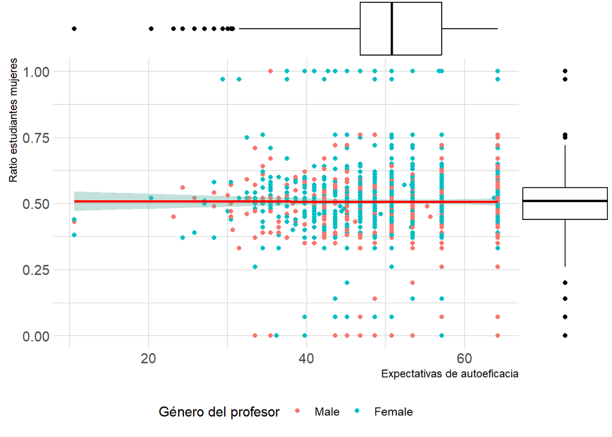

```r
ggMarginal(teacher%>%

             ggplot(aes(x=t_eff,y=gen_ratio_grade,color=to_label(t_sex)))+
             geom_point()+
             geom_smooth(method=lm , color="red", se=TRUE,fill="#69b3a2")+
             theme_ipsum()+
             labs(x = "Expectativas de autoeficacia",
                  y = "Ratio estudiantes mujeres",
                  color= "Género del profesor")+
             theme(legend.position = "bottom"),

        type = "boxplot")
```

Se comprueba esto último viendo las medias de autoeficacia por género. No hay diferencias mayores, lo cual es consistente con la literatura.

```r
teacher %>% group_by(to_label(t_sex)) %>% summarise(media_autoeficacia=mean(t_eff, na.rm=T))%>%rename(sexo_profesor="to_label(t_sex)")%>%kable()
```

| sexo_profesor | media_autoeficacia |
| --- | --- |
| Male | 53.07156 |
| Female | 51.18289 |

# Presentación de variables 2018